[figure not shown]

# Global Atmospheric Grid Point Model

# Globagrim

- **Task**:
  - Perform numerical weather & climate simulations on your PC
  - Enhance educational understanding of numerical weather & climate models
- **Simplification**
  - Only atmoshpere
  - Neglet external forcings (sun, CO<sub>2</sub>)

# Numerical Atmospheric Model

- Uses mathematical equations to predict the future state of the the atmosphere
- Spatial domain and time interval are discretized (broken in finite number of steps)
- Numerical stability depends on
  - Distance between model grid points
  - Model time step length

[figure not shown]

# Installation

Create a conda environment with

`conda env create -f environment.yml`

This installs GLOBAGRIM and all dependencies. Then, activate the environment with:

`conda activate globagrim_env`

### Alternative

If you already have `numpy`, `xarray`, `netcdf4`, `matplotlib`, `cartopy`, `jupyter` installed, you can also add the GLOBAGRIM package to your current environment by executing:

`pip install git+git://github.com/MarcoKulueke/globagrim_project.git#egg=globagrim`

# Usage

```python
from globagrim import model
```

```python
model.run()
```

```
Number of longitudes:  144
Number of latitudes:  72
Number of model time steps:  6
Output every  1  model time steps
Init:  /Users/marco/Documents/globagrim_project/output.nc
Write initial conditions to output.
---
Model time step:  0 , Elapsed model time:  0.25  minutes
Write to output
---
Model time step:  1 , Time:  0.5  minutes
Write to output
---
Model time step:  2 , Time:  0.75  minutes
Write to output
---
Model time step:  3 , Time:  1.0  minutes
Write to output
---
Model time step:  4 , Time:  1.25  minutes
Write to output
---
Model time step:  5 , Time:  1.5  minutes
Write to output
---
```

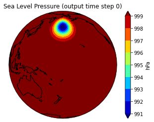

```python
model.plot()
```

# Optional Parameters

## `run()`

- `NJ` Number of west-east circles of longitude
- `NK` Number of north-south circles of latitude
- `NL` Number of vertical levels
- `TF` Total integration time in hours
- `DT` Integration time step in seconds
- `IEXP` Experiment number (`1` low pressure system over the Pacific, `2` stream over montain in North America, `3` random wind field)
- `INT` Output intervall in hours
- `OUT` Output path and file name

Example:

`model.run(NJ=80, NK=40, NL=10, TF=0.5, DT=30, IEXP=2, INT=0.1, OUT='test.nc')`

### IEXP = 1 (low pressure system over the Pacific)

[figure not shown]

### IEXP = 2 (stream over montain in North America)

[output not shown]

### IEXP = 3 (random wind field)

[output not shown]

[figure not shown]

## `plot()`

- `var_name` String variable name (`SE`, `PSG`, `T`, `U`, `V`)
- `out_step` Integer output time step
- `center` Touple `(<lon>,<lat>)` for center of visualization
- `min_max` Touple `(<min>,<max>)` for a fixed colorbar
- `save` String (e.g. `test.png`)

Example:

`model.plot(var_name='U', out_step=4, center=(-180, 50), min_max=(0,20), save='test.png')`

# Now, it's your Turn

- Play around with space and time
- Try different experiments
- Can you make the model crash?
- Visualize where and when the crash happens
- [...]

| model.run() | model.plot() |
| --- | --- |
| `NJ` Number of west-east circles of longitude | `var_name` String variable name (`SE`, `PSG`, `T`, `U`, `V`) |
| `NK` Number of north-south circles of latitude | `out_step` Integer output time step |
| `NL` Number of vertical levels | `center` Touple `(<lon>,<lat>)` for center of visualization |
| `TF` Total integration time in hours | `min_max` Touple `(<min>,<max>)` for a fixed colorbar |
| `DT` Integration time step in seconds | `save` String (e.g. `test.png`) |
| `IEXP` Experiment number (`1` low, `2` mountain stream, `3` random wind) |  |
| `INT` Output intervall in hours |  |
| `OUT` Output path and file name |  |